# Offene SNF-Daten: Wer erhält Förderung? So berechnen Sie selber Detailzahlen

30.11.2022

**Der SNF macht Daten zu seiner Forschungsförderung öffentlich zugänglich. Wir zeigen auf, wie Sie diese Daten einfach und schnell zur Berechnung nützlicher Zahlen verwenden können.**

Auf dem [Datenportal](https://data.snf.ch/) bietet der SNF [eine Reihe von Datensätzen](https://data.snf.ch/datasets) an. Es handelt sich dabei um Detailinformationen zu den geförderten Projekten, deren Output und den beteiligten Personen.

Wie lassen sich diese Daten nutzen? In einer Serie von Datengeschichten stellen wir Ihnen mögliche Analysen mit der Programmiersprache R vor. Im ersten Artikel erläutern wir:

- das Herunterladen von Daten der geförderten SNF-Projekte
- die Berechnung von jährlichen Zahlen
- die Bestimmung des Förderumfangs nach Disziplinen
- und die Berechnung der Wissenschaftsgebiete der Institutionen.

Was die Programmiersprache R genau ist, erfahren Sie in einem Abschnitt am Ende des Haupttextes; Informationen zur Datenanalyse mit Microsoft Excel finden Sie im untenstehenden Kasten. Aufgrund von vielfältigeren Analysemöglichkeiten wird für diese Datengeschichte R gebraucht.

### Verwendung anderen Tools für die Analyse

#### Excel

Um die Analyse unserer Daten auch mit Microsoft Excel zu erleichtern, bieten wir auf dem Datenportal SNF-Daten zusätzlich zum CSV-Format im Excelformat an.

- Wenn Sie die Resultate einer ausgeführten [Projektsuche](https://data.snf.ch/grants) als Excel herunterladen wollen, klicken Sie auf “Resultate herunterladen” am Ende der Resultateseite und wählen Sie “.XLSX”. Um alle der Projektsuche zugrundeliegenden Daten als Excel herunterzuladen, klicken Sie auf “Download XLSX” auf der [Seite der Datensätze](https://data.snf.ch/datasets).
- Um Daten der “[SNF-Kennzahlen](https://data.snf.ch/key-figures/)” herunterzuladen, klicken Sie auf der jeweiligen Seite auf “Download (Excel)”.

Im Reiter “Daten” in Excel können die Daten sortiert und filtriert werden. Mit der Funktion “PivotTable” lassen sie sich gruppieren und aufsummieren.

#### Python

Für eine Implementierung des Codes in Python, bitte konsultieren Sie [die von Patrick Arnecke erstellte Version auf Github](https://github.com/rnckp/opendata_snsf-startercode).

### Daten herunterladen

Zuerst laden wir die Daten zu den geförderten Beiträgen in unsere R-Umgebung und filtrieren das Zeitfenster von 2011 bis 2021. Für die Zuordnung eines Beitrags zu einem Jahr verwenden wir das Jahr, in dem die Entscheide der jeweiligen Ausschreibung gefällt wurden, das `CallDecisionYear`. Dann werfen wir einen Blick auf die in den Daten vorhandenen Variablen.

```r
# Load tidyverse packages to gather, manipulate and visualize data
library(tidyverse)

# Download all funded grants since 1975
grants <- read_delim("https://data.snf.ch/exportcsv/Grant.csv") %>%
  # Subset years 2011-2021
  filter(CallDecisionYear >= 2011, CallDecisionYear <= 2021)

# Quick look at the available variables
grants %>%
  glimpse(width = 80)
```

```
## Rows: 32,055
## Columns: 24
## $ AllDisciplines             <chr> "10203", "10403", "30104/30302", "10201/102…
## $ AmountGrantedAllSets       <dbl> 5860, 83575, 148700, 19600, 419221, 48700, …
## $ CallDecisionYear           <dbl> 2011, 2014, 2013, 2018, 2013, 2017, 2018, 2…
## $ CallEndDate                <dttm> NA, 2014-09-01, 2013-04-01, 2018-12-31, 20…
## $ CallFullTitle              <chr> NA, "Early Postdoc.Mobility 2014 (01.09.201…
## $ EffectiveGrantEndDate      <dttm> 2012-02-29, 2016-12-31, 2014-03-31, 2018-0…
## $ EffectiveGrantStartDate    <dttm> 2012-01-01, 2015-07-01, 2013-10-01, 2018-0…
## $ FundingInstrumentLevel1    <chr> "Careers", "Careers", "Careers", "Science c…
## $ FundingInstrumentPublished <chr> "International short research visits", "Ear…
## $ FundingInstrumentReporting <chr> "International short research visits", "Fel…
## $ GrantNumber                <dbl> 141564, 158787, 148385, 180928, 146546, 178…
## $ GrantNumberString          <chr> "IZK0Z1_141564", "P2SKP1_158787", "P3SMP3_1…
## $ Institute                  <chr> NA, "Program in Medical Anthropology Depart…
## $ InstituteCountry           <chr> NA, "United States of America", NA, "Switze…
## $ Keywords                   <chr> "Gender; Marriage; Divorce; Education; Risk…
## $ MainDiscipline             <chr> "Economics", "Ethnology", "Neurophysiology …
## $ MainDiscipline_Level1      <chr> "Humanities and Social Sciences", "Humaniti…
## $ MainDiscipline_Level2      <chr> "Economics, law", "Ethnology, social and hu…
## $ MainDisciplineNumber       <dbl> 10203, 10403, 30302, 10202, 10201, 10203, 2…
## $ ResearchInstitution        <chr> "University of Zurich - ZH", "Institution a…
## $ ResponsibleApplicantName   <chr> "Rendall, Michelle", "Begrich, Roger", "Krs…
## $ State                      <chr> "Completed", "Completed", "Completed", "Com…
## $ Title                      <chr> "Emancipation Through Education", "Pharmace…
## $ TitleEnglish               <chr> NA, "Pharmaceutical Relations. Ethnography …
```

Im Konsolenoutput sehen wir, dass gemäss der Filtrierung insgesamt 32’055 Beiträge zwischen 2011 und 2021 bewilligt wurden. Die im Output ersichtlichen Variablen sind [im Glossar des Datenportals](https://data.snf.ch/about/glossary) dokumentiert. Die Daten sind nun bereit für die Analyse.

### Jährliche Zahlen berechnen

Im nächsten Schritt wollen wir wissen, wie sich die Fördermenge des SNF über die Jahre entwickelt hat. Dafür gruppieren wir zuerst die Beiträge pro Jahr (Variable `CallDecisionYear`), zählen die Anzahl Beiträge und summieren den gesprochenen Betrag (Variable `AmountGrantedAllSets`) auf. Um die Entwicklung besser einschätzen zu können, erstellen wir ein einfaches Liniendiagramm mit dem R-Package [`ggplot2`](https://ggplot2.tidyverse.org/).

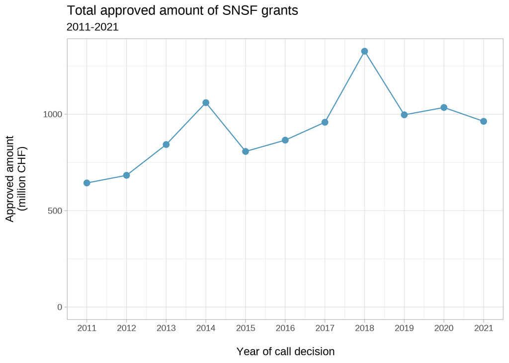

```r
# Load ggplot2 package to create data visualisations
library(ggplot2)

# Calculate how much the SNSF granted per year from 2011 to 2021. The total
# amount of a grant is allocated to the year in which the grant was awarded.
granted_per_year <- grants %>%
  group_by(CallDecisionYear) %>%
  summarise(
    # Total granted in million CHF per year. The total amount of a grant is
    # allocated to the year in which the grant was awarded.
    total_granted = sum(AmountGrantedAllSets, na.rm = TRUE) / 1000000,
    # Number of grants
    n_grants = n()
  ) %>%
  ungroup()

# Plot funding per year
granted_per_year %>%
  ggplot(aes(x = CallDecisionYear, y = total_granted)) +
  geom_line(size = 0.5, color = "#5298BD") +
  geom_point(size = 2.5, color = "#5298BD") +
  scale_x_continuous(breaks = seq(2011, 2021, 1)) +
  # Start y-axis at zero
  scale_y_continuous(limits = c(0, max(granted_per_year$total_granted), 200)) +
  labs(title = "Total approved amount of SNSF grants",
       x = "\nYear of call decision", y = "Approved amount\n(million CHF)\n",
       subtitle = paste0(min(granted_per_year$CallDecisionYear), "-",
       max(granted_per_year$CallDecisionYear))) +
  theme_light()
```

Die Fördermenge des SNF nahm von 644 Millionen Franken im Jahr 2011 auf 963 Millionen Franken im Jahr 2021 zu[^1]. Das ist eine Steigerung um 49,6 Prozent (ohne Teuerungsbereinigung). Die zwei Spitzen in 2014 und 2018 bestehen aufgrund der Lancierung neuer [Nationaler Forschungsschwerpunkte (NFS)](https://www.snf.ch/de/EcRzGgwFJMZjfnNc/seite/nationale-forschungsschwerpunkte-nfs) in diesen Jahren. Dies kann man herausfinden, indem man die einzelnen Projekte und deren Betrag in den beiden Jahren einzeln durchgeht (mittels `View(grants)` lassen sich alle Förderbeiträge als Tabelle ausgeben).

Wenn wir mehr ins Detail gehen wollen, können wir auch die Förderkategorie (Projekte oder Projektförderung, Karrieren, Programme, Infrastrukturen, Wissenschaftskommunikation) mit in die Gruppierung nehmen (mit der Variable `FundingInstrumentLevel1`) und dann die gesprochenen Beträge pro Kategorie separat darstellen.

[output not shown]

[figure not shown]

### Förderumfang nach Disziplinen

Dann wollen wir herausfinden, welche Disziplinen in den letzten Jahren die grössten Fördermengen erhalten haben. Dafür gruppieren wir die Beträge nach der von der gesuchstellenden Person festgelegten Hauptdisziplin (Variable `MainDiscipline`), sortieren die Werte nach ihrer Grösse (in Millionen Franken), und geben die zehn Disziplinen mit den grössten Beträgen in einer Tabelle aus. Anmerkung: Von der Fördermenge können keine Erfolgsquoten abgeleitet werden.

```r
# Calculate per main discipline: funding, number of grants, funding share
most_funded_disciplines <- grants %>%
  # Remove Sinergia grants due to their interdisciplinary nature
  filter(FundingInstrumentReporting != "Sinergia") %>%
  group_by(MainDiscipline) %>%
  summarise(
    # Total granted in million CHF per year. The total amount of a grant is
    # allocated to the year in which the grant was awarded.
    total_granted = sum(AmountGrantedAllSets, na.rm = TRUE) / 1000000,
    n_grants = n()
  ) %>%
  ungroup() %>%
  # Calculate funding for each main discipline
  mutate(share = 100 * (total_granted / sum(total_granted))) %>%
  # Subset the 10 main disciplines with the biggest volume
  arrange(desc(total_granted)) %>%
  slice(1:10)

# Print table
most_funded_disciplines %>%
  knitr::kable()
```

| MainDiscipline | total_granted | n_grants | share |
| --- | --- | --- | --- |
| Neurophysiology and Brain Research | 357.0160 | 961 | 3.773627 |
| Molecular Biology | 344.2651 | 906 | 3.638852 |
| Condensed Matter Physics | 332.9130 | 847 | 3.518861 |
| Mathematics | 282.7942 | 850 | 2.989110 |
| Psychology | 276.5546 | 1087 | 2.923157 |
| Physical Chemistry | 271.7400 | 649 | 2.872268 |
| Immunology, Immunopathology | 261.5720 | 644 | 2.764792 |
| Sociology | 255.1776 | 830 | 2.697204 |
| Material Sciences | 249.5738 | 604 | 2.637973 |
| Information Technology | 229.8420 | 841 | 2.429410 |

Wir sehen also, dass mit 357 Millionen Franken oder 3,8 Prozent Anteil am Fördervolumen die grösste Förderung an 961 Projekte in der Hauptdisziplin “Neurophysiology and Brain Research” (Neurophysiologie und Hirnforschung) ging.

### Wissenschaftsgebiete pro Institution

Zuletzt wollen wir wissen, wie sich die Vertretung der drei Wissenschaftsgebiete in SNF-geförderten Projekten an den Schweizer Institutionen unterscheidet. Die Disziplinen der Beiträge in den Daten lassen sich jeweils einem der drei Gebiete zuordnen, den Geistes- und Sozialwissenschaften (GSW, “Humanities and Social Sciences”), den Mathematik, Natur- und Ingenieurwissenschaften (MINT, “Mathematics, Natural- and Engineering Science”) und den Lebenswissenschaften (LW, “Biology and Medicine”). Die Variable `ResearchInstitution` beinhaltet die Institution, an der die Forschung des jeweiligen Beitrags hauptsächlich stattfindet – diese entspricht in den meisten Fällen der Institution der verantwortlichen gesuchstellenden Person. Um die Vergleichbarkeit zu verbessern, beschränken wir uns auf die Projektförderung in den grösseren Institutionen. Wir filtrieren daher im ersten Schritt das Förderinstrument Projektförderung (Variable `FundingInstrumentLevel1`) und behalten nur diejenigen Institutionen, an denen Forschende 50 Beiträge zwischen 2011 und 2021 zugesprochen wurden.

```r
# Create a vector with institutions with more than 50 grants between 2011-2021
inst_above_50_grants <- grants %>%
  # Subset project funding
  filter(FundingInstrumentLevel1 == "Projects") %>%
  count(ResearchInstitution, sort = TRUE) %>%
  # Keep only institutions with with more than 50 grants
  filter(n > 50)

inst_above_50_grants
```

```
## # A tibble: 22 × 2
##    ResearchInstitution                          n
##    <chr>                                    <int>
##  1 University of Zurich - ZH                 1570
##  2 ETH Zurich - ETHZ                         1566
##  3 University of Geneva - GE                 1227
##  4 EPF Lausanne - EPFL                       1158
##  5 University of Berne - BE                  1143
##  6 University of Lausanne - LA                947
##  7 University of Basel - BS                   913
##  8 University of Fribourg - FR                439
##  9 Paul Scherrer Institute - PSI              300
## 10 Università della Svizzera italiana - USI   240
## # … with 12 more rows
```

Von den insgesamt 79 Institutionen, denen im untersuchten Zeitraum in der Projektförderung Grants zugesprochen wurden, haben 22 über 50 Beiträge - diese 22 untersuchen wir weiter.

Zuerst zählen wir, wie viele SNF-Beiträge pro Wissenschaftsgebiet an die jeweiligen Institutionen gingen. Dann rechnen wir pro Institution aus, welchem Anteil dies entspricht. Schliesslich zeigen wir die Anteile der Institutionen alphabetisch geordnet in einem gestapelten Balkendiagramm an.

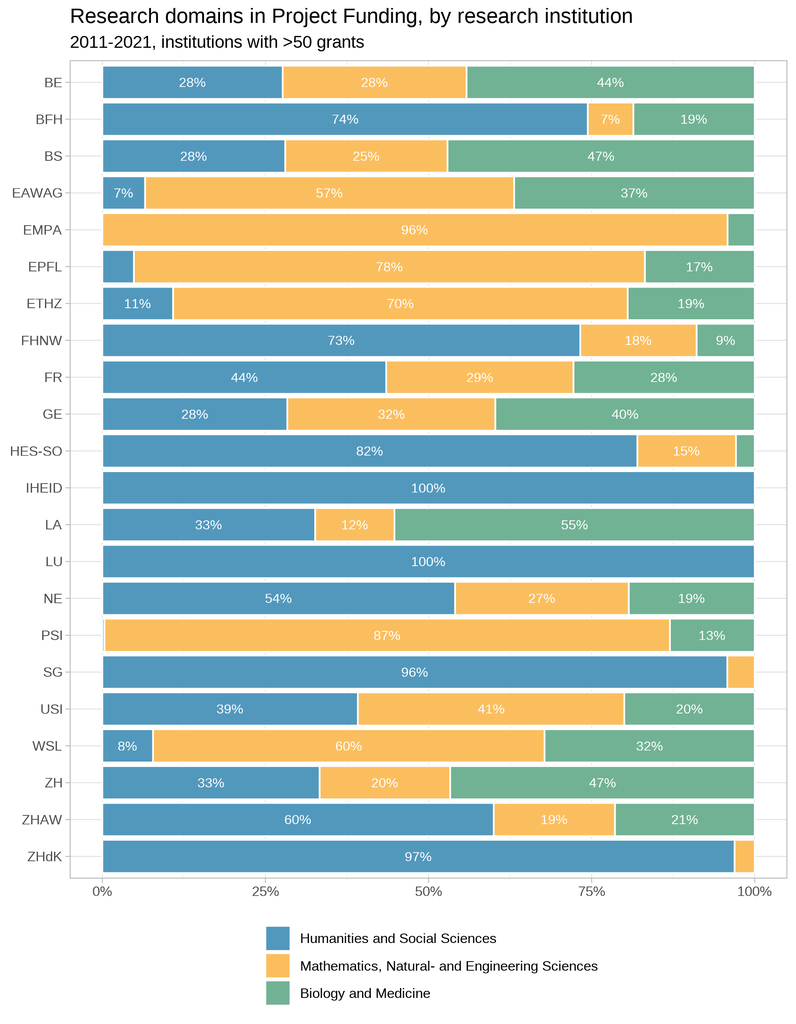

```r
# Project funding SSH/MINT/LS: Calculate the shares of each research domain in
# the number of grants per funded research institution (2011-2021)
inst_research_domain_sharesn <- grants %>%
  # Subset project funding
  filter(FundingInstrumentLevel1 == "Projects",
         # Only the institutions more than 50 grants
         ResearchInstitution %in% inst_above_50_grants$ResearchInstitution) %>%
  count(ResearchInstitution, MainDiscipline_Level1) %>%
  # Calculate the share of each institution
  group_by(ResearchInstitution) %>%
  mutate(freq = n / sum(n)) %>%
  # Count the number of grants per research domain in each institution
  ungroup() %>%
  # The institution names are too long for the graph, only keep their
  # abbreviation (after the "-" character in the name)
  mutate(ResearchInstitution = str_extract(ResearchInstitution,
                                           "(?<=- ).*"),
         # Ordering of the research domains
         MainDiscipline_Level1 = fct_relevel(
           MainDiscipline_Level1,
           c("Humanities and Social Sciences",
             "Mathematics, Natural- and Engineering Sciences",
             "Biology and Medicine")))

# Plot the shares
inst_research_domain_sharesn %>%
  ggplot(aes(x = fct_rev(ResearchInstitution),
             y = freq, fill = fct_rev(MainDiscipline_Level1))) +
  geom_col(color = "white") +
  # Show percentage label, but only when the share is at least 5%
  geom_text(aes(label =  if_else(freq >= 0.05, paste0(round(freq * 100), "%"),
                                 "")),
            position = position_stack(vjust = 0.5), color = "white", size = 3) +
  scale_y_continuous(labels = scales::percent_format(accuracy = 1)) +
  labs(x = NULL, y = NULL) +
  # Override ggplot default theme
  scale_fill_manual(values = c("#71B294", "#FBBE5E", "#5298BD"),
                    guide = guide_legend(reverse = TRUE, ncol = 1)) +
  coord_flip() +
  labs(title = "Research domains in Project Funding, by research institution",
    subtitle = paste0(min(granted_per_year$CallDecisionYear), "-",
       max(granted_per_year$CallDecisionYear),
       ", institutions with >50 grants")) +
  theme_light() +
  theme(legend.position = "bottom",
        legend.title = element_blank())
```

Die Grafik zeigt, dass die Anteile der Wissenschaftsgebiete von SNF-Projekten an den verschiedenen Institutionen sehr unterschiedlich sind. 80 Prozent und mehr der Projekte der Fachhochschule Westschweiz (HES-SO), des Graduate Institute Genf (IHEID), der Universitäten Luzern (LU) und St. Gallen (SG) sowie der Zürcher Hochschule der Künste (ZHdK) fallen in den Bereich der Geistes- und Sozialwissenschaften. Projekte an der Eidgenössischen Materialprüfungs- und Forschungsanstalt (EMPA) sowie dem Paul Scherrer Institut (PSI) fallen zu über 80 Prozent in den Bereich der MINT-Disziplinen. Unter den aufgelisteten Institutionen finden sich keine, die einen derart grossen Anteil an Projekten in den Lebenswissenschaften haben. Mit 55 Prozent ist der Lebenswissenschaften-Anteil an der Universität Lausanne am höchsten.

### Einführung in R

[R](https://www.r-project.org/) ist eine kostenlose Programmiersprache, die sich insbesondere für statistische Berechnungen und das Erstellen von Datenvisualisierungen eignet. Als Entwicklungsumgebung empfehlen wir das ebenfalls kostenlose [RStudio](https://www.rstudio.com/). Weiterführende Links:

- [Installation von R und RStudio auf Windows, Mac und Linux](https://rstudio-education.github.io/hopr/starting.html)
- [Einstieg in R und das `tidyverse`: “R for Data Science”](https://r4ds.had.co.nz/)
- [Erstellen von Datenvisualisierungen mit dem Package `ggplot2`: “ggplot2: elegant graphics for data analysis”](https://ggplot2-book.org/)

*In einer Serie von Datengeschichten zeigen wir auf, wie Sie offene Daten des SNF für Analysen zur Forschungsförderung verwenden können. Um die Praxisnähe und Reproduzierbarkeit zu erhöhen, haben wir den Code der Programmiersprache R direkt in dieser Geschichte gezeigt.*

Daten, Text und Code dieser Datengeschichte sind [auf Github verfügbar](https://github.com/snsf-data/datastory_use_snsf_open_data) und [auf Zenodo archiviert](https://doi.org/10.46446/datastory.use-snsf-open-data). DOI: 10.46446/datastory.use-snsf-open-data

[^1]: Die in dieser Datengeschichte analysierten Zahlen sind grösser als die in den [SNF-Kennzahlen](https://data.snf.ch/key-figures/funding-instruments) dargestellten Zahlen. Der Unterschied besteht darin, dass die im hier verwendeten Datendownload enthaltenen Daten auch Zahlen zu den [Nationalen Forschungsschwerpunkten (NFS)](https://www.snf.ch/de/EcRzGgwFJMZjfnNc/seite/nationale-forschungsschwerpunkte-nfs) beinhalten, [die bei den Kennzahlen separat ausgewiesen werden.](https://data.snf.ch/key-figures/nccr)